# heat map

- Show All Code
- Hide All Code
- View Source

## 1 Introduction

Email from Baydoun, May Ahmad on Feb 06, 2023.

**Instructions in May’s email**

I hope you are doing well. I just completed the analysis for another UKB paper and I would like to invite you, Yi-Han and Dr. Launer on it.

This is not in a hurry at all, but since I finished this part, I thought I will pass it by to you.

I will need to include a similar heat map as for UKB paper #4, but instead of FA and MD, this time it would be for ISOVF, ICVF and OD.

I am attaching the excel file here along with the previous code that you sent me.

This should be a lot easier than the previous time.

Here is the tentative title, with potential co-authors. As usual, the order of the co-authors might change and I may have to add more later on or remove some if unavailable to help out.

Infection burden and its association with neurite orientation dispersion and density imaging markers in the UK biobank

## 2 Load data

```r
d <- read_excel("../File_from_may/FIGURE2_HEATMAP.xlsx", sheet = "HEATMAP_DATA") |>
  clean_names()


glimpse(d)
```

```
Rows: 147
Columns: 16
$ parmseq             <dbl> 1, 1, 1, 1, 1, 1, 1, 1, 1, 1, 1, 1, 1, 1, 1, 1, 1,…
$ outcome             <chr> "zISOVF_PLIC_Left", "zISOVF_PLIC_Right", "zISOVF_A…
$ idnum               <dbl> 28, 29, 3, 39, 1, 4, 40, 122, 43, 5, 146, 32, 127,…
$ parm                <chr> "infectionburdentert", "infectionburdentert", "inf…
$ label               <chr> "3 quantiles of infectionburden", "3 quantiles of …
$ estimate            <dbl> 0.07, 0.06, 0.06, 0.05, 0.05, 0.04, 0.04, 0.04, 0.…
$ stderr              <dbl> 0.00575826, 0.00556180, 0.00558258, 0.00547268, 0.…
$ dof                 <dbl> 38696, 38696, 38696, 38696, 38696, 38696, 38696, 3…
$ t                   <dbl> 12.021578, 10.235896, 9.865835, 9.667436, 9.639565…
$ p                   <dbl> 3.1e-33, 1.5e-24, 6.2e-23, 4.4e-22, 5.8e-22, 1.3e-…
$ min95               <dbl> 0.06, 0.05, 0.04, 0.04, 0.04, 0.03, 0.03, 0.03, 0.…
$ max95               <dbl> 0.08, 0.07, 0.07, 0.06, 0.06, 0.05, 0.05, 0.05, 0.…
$ uncp                <dbl> 0.05, 0.05, 0.05, 0.05, 0.05, 0.05, 0.05, 0.05, 0.…
$ corp                <dbl> 0.00034014, 0.00034014, 0.00034014, 0.00034014, 0.…
$ signif              <dbl> 1, 1, 1, 1, 1, 1, 1, 1, 1, 1, 1, 1, 1, 1, 1, 1, 1,…
$ myqvallargervolumes <dbl> 4.6120e-31, 1.0820e-22, 3.0530e-21, 1.6140e-20, 1.…
```

## 3 data reorganizing

### 3.1 Basic reorganizing

1. Remove unnecessary rows.
2. Add “Left” and “Right” side to the regions missing such indication
3. Separate “outcome” column
4. Remove the first letter “z” in MRI variable

```r
d_reorg <-
  d |>
  select(outcome, estimate, p, myqvallargervolumes) |>
  # Remove the two "mean" records
  filter(! str_detect(outcome, "mean")) |>
  # Indicate the rows without "_Left" or "_Right" in the outcome column as "YES" for uniside variable
  mutate(uniside = if_else(str_detect(outcome, regex("Left$|Right$", ignore_case = TRUE)), "NO", "YES")) |>
  # Create "rep" as replicating weight for the next step
  mutate(rep = if_else(uniside == "NO", 1, 2)) |>
  # Use uncount() function to do the replication
  uncount(weights = rep, .id = "id", .remove = FALSE) |>
  # Append "_Left" or "_Right" in the outcome records that originally have no Left or Right tagged
  mutate(
    outcome = case_when(
      rep == 2 & id == 1 ~ str_c(outcome, "_Left"),
      rep == 2 & id == 2 ~ str_c(outcome, "_Right"),
      TRUE ~ outcome
    )
  ) |>
  separate(outcome, c("MRI", "region", "side")) |>
  # All the "MRI" starts with letter "z". Remove it.
  mutate(MRI = str_remove(MRI, "^z"))

glimpse(d_reorg)
```

```
Rows: 162
Columns: 9
$ MRI                 <chr> "ISOVF", "ISOVF", "ISOVF", "ISOVF", "ISOVF", "ISOV…
$ region              <chr> "PLIC", "PLIC", "ALIC", "SCR", "ACR", "ALIC", "SCR…
$ side                <chr> "Left", "Right", "Left", "Left", "Left", "Right", …
$ estimate            <dbl> 0.07, 0.06, 0.06, 0.05, 0.05, 0.04, 0.04, 0.04, 0.…
$ p                   <dbl> 3.1e-33, 1.5e-24, 6.2e-23, 4.4e-22, 5.8e-22, 1.3e-…
$ myqvallargervolumes <dbl> 4.612e-31, 1.082e-22, 3.053e-21, 1.614e-20, 1.694e…
$ uniside             <chr> "NO", "NO", "NO", "NO", "NO", "NO", "NO", "YES", "…
$ rep                 <dbl> 1, 1, 1, 1, 1, 1, 1, 2, 2, 1, 2, 2, 1, 1, 1, 1, 1,…
$ id                  <int> 1, 1, 1, 1, 1, 1, 1, 1, 2, 1, 1, 2, 1, 1, 1, 1, 1,…
```

### 3.2 Convert to wide format

```r
d_wide <-
  d_reorg |>
  pivot_wider(
    id_cols = region,
    names_from = c(MRI, side),
    # values_from = c(estimate, rep)
    values_from = c(estimate, uniside)
  )

glimpse(d_wide)
```

```
Rows: 27
Columns: 13
$ region               <chr> "PLIC", "ALIC", "SCR", "ACR", "MCP", "SLF", "BCC"…
$ estimate_ISOVF_Left  <dbl> 0.07, 0.06, 0.05, 0.05, 0.01, 0.04, 0.03, 0.00, 0…
$ estimate_ISOVF_Right <dbl> 0.06, 0.04, 0.04, 0.03, 0.01, 0.00, 0.03, -0.01, …
$ estimate_OD_Left     <dbl> 0.03, 0.01, 0.01, 0.01, 0.04, 0.01, 0.00, 0.03, 0…
$ estimate_OD_Right    <dbl> 0.03, 0.03, 0.01, 0.01, 0.04, 0.02, 0.00, 0.03, 0…
$ estimate_ICVF_Left   <dbl> 0.01, 0.01, 0.00, 0.00, 0.00, 0.00, -0.01, -0.01,…
$ estimate_ICVF_Right  <dbl> 0.01, 0.00, 0.00, -0.01, 0.00, -0.01, -0.01, -0.0…
$ uniside_ISOVF_Left   <chr> "NO", "NO", "NO", "NO", "YES", "NO", "YES", "NO",…
$ uniside_ISOVF_Right  <chr> "NO", "NO", "NO", "NO", "YES", "NO", "YES", "NO",…
$ uniside_OD_Left      <chr> "NO", "NO", "NO", "NO", "YES", "NO", "YES", "NO",…
$ uniside_OD_Right     <chr> "NO", "NO", "NO", "NO", "YES", "NO", "YES", "NO",…
$ uniside_ICVF_Left    <chr> "NO", "NO", "NO", "NO", "YES", "NO", "YES", "NO",…
$ uniside_ICVF_Right   <chr> "NO", "NO", "NO", "NO", "YES", "NO", "YES", "NO",…
```

### 3.3 Remove duplicated columns

```r
d_dedup <-
  d_wide[!duplicated(as.list(d_wide))] |> #glimpse()
  rename_with(~ str_replace(.x, "uniside_.*", "uniside")) |>
  rowwise() |>
  mutate(mean_ISOVF = mean(c_across(contains("ISOVF"))),
         mean_OD = mean(c_across(contains("OD"))),
         mean_ICVF = mean(c_across(contains("ICVF"))),
         mean_all = mean(c_across(contains("estimate")))
         ) |>
  arrange(desc(mean_ISOVF), desc(mean_OD), desc(mean_ICVF))

glimpse(d_dedup)
```

```
Rows: 27
Columns: 12
Rowwise:
$ region               <chr> "PLIC", "ALIC", "SCR", "ACR", "BCC", "GCC", "ML",…
$ estimate_ISOVF_Left  <dbl> 0.07, 0.06, 0.05, 0.05, 0.03, 0.03, 0.03, 0.04, 0…
$ estimate_ISOVF_Right <dbl> 0.06, 0.04, 0.04, 0.03, 0.03, 0.03, 0.03, 0.00, 0…
$ estimate_OD_Left     <dbl> 0.03, 0.01, 0.01, 0.01, 0.00, 0.00, -0.02, 0.01, …
$ estimate_OD_Right    <dbl> 0.03, 0.03, 0.01, 0.01, 0.00, 0.00, 0.00, 0.02, 0…
$ estimate_ICVF_Left   <dbl> 0.01, 0.01, 0.00, 0.00, -0.01, -0.01, 0.02, 0.00,…
$ estimate_ICVF_Right  <dbl> 0.01, 0.00, 0.00, -0.01, -0.01, -0.01, 0.01, -0.0…
$ uniside              <chr> "NO", "NO", "NO", "NO", "YES", "YES", "NO", "NO",…
$ mean_ISOVF           <dbl> 0.065, 0.050, 0.045, 0.040, 0.030, 0.030, 0.030, …
$ mean_OD              <dbl> 0.030, 0.020, 0.010, 0.010, 0.000, 0.000, -0.010,…
$ mean_ICVF            <dbl> 0.010, 0.005, 0.000, -0.005, -0.010, -0.010, 0.01…
$ mean_all             <dbl> 0.035000000, 0.025000000, 0.018333333, 0.01500000…
```

### 3.4 Function to covert tibble to matrix

```r
make_matrix <- function(df, matrix_col, rowname_col = NULL) {
  my_matrix <- df %>%
    select({{ matrix_col }}) %>%
    as.matrix()

  if (!is.null(rownames)) {
    rownames(my_matrix) <- pull(df, {{ rowname_col }})
  }

  my_matrix
}
```

## 4 Make heatmap

### 4.1 Annotations for heatmap

```r
# "Left" or "Right" side as a char vector
side <-
  d_dedup |>
  select(contains("estimate")) |>
  colnames(x=_) |>
  str_extract("Left|Right")


# MRI and side as a char vector for heatmap column annotation
MRI <-
  d_dedup |>
  select(contains("estimate")) |>
  # colnames(x=_) #|>
  colnames() |>
  str_extract("ISOVF|ICVF|OD")


MRI_mean <-
  d_dedup |>
  ungroup() |>
  summarise(across(contains("estimate"), ~ mean(.x, na.rm=TRUE))) |>
  pivot_longer(cols = everything()) |>
  deframe()

# row_ha <- rowAnnotation(Uniside = d_dedup$uniside, col = list(Uniside = c("YES" = "red", "NO" = "green")))
row_ha <- rowAnnotation(Uniside = d_dedup$uniside, col = list(Uniside = set_names(hue_pal(h.start = 60)(2), unique(d_dedup$uniside))))
# column_ha = HeatmapAnnotation(MRI = MRI, side = side)
column_ha = HeatmapAnnotation(
  # mean=anno_barplot(MRI_mean, border = FALSE),
  MRI = MRI,
  side = side,
  col = list(
    MRI = set_names(brewer.pal(3, "Paired"), unique(MRI)),
    # side = set_names(hue_pal(h.start = 60)(2), unique(side))
    side = set_names(viridis(n=2, option = "D"), unique(side))
  )
)
```

### 4.2 Heatmap

**Uniside**

Uniside denotes the MRI regions have no left/right sides. The same values were replicated and asigned to left/right sides to make the heatmap.

#### Order by mean values

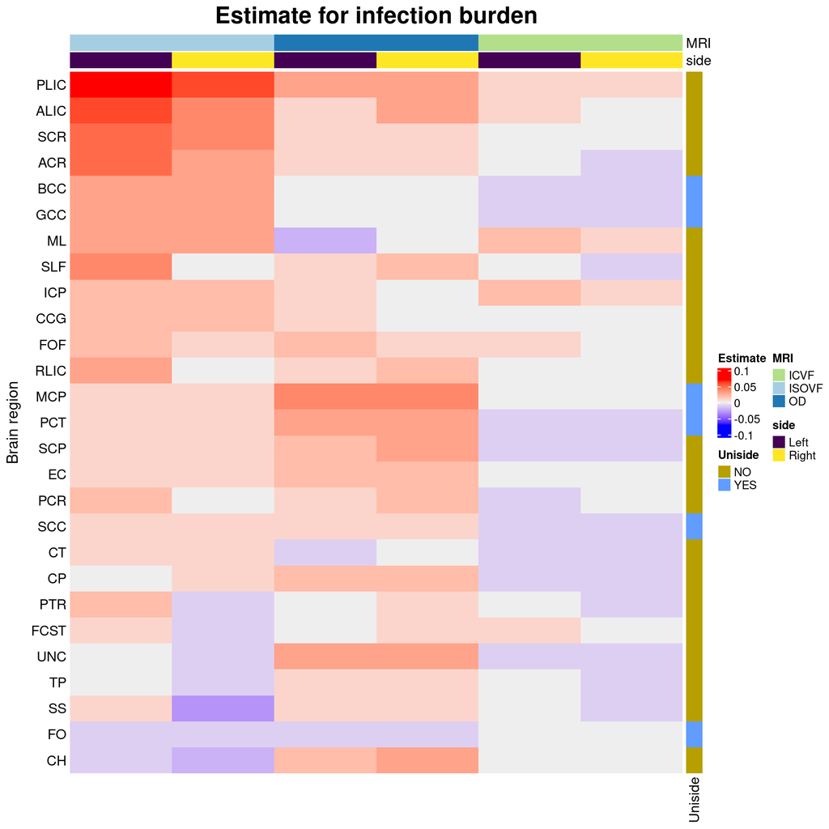

```r
d_dedup |>
  make_matrix(matrix_col = contains("estimate"), rowname_col = region) %>%
  Heatmap(
   name = "Estimate",
   cluster_columns = FALSE,
   cluster_rows = FALSE,
   show_row_names = TRUE,

   # Title
   row_title = "Brain region",
   row_title_side = "left",
   column_title = "Estimate for infection burden",
   column_title_gp = gpar(fontsize = 20, fontface = "bold"),

   # Names
   row_names_side = "left",
   # column_names_rot = 60,
   # column_names_centered = TRUE,
   show_column_names = FALSE,

   # Annotation
   right_annotation = row_ha,
   top_annotation = column_ha
  )
```

#### Order by multidimentional scaling (MDS)

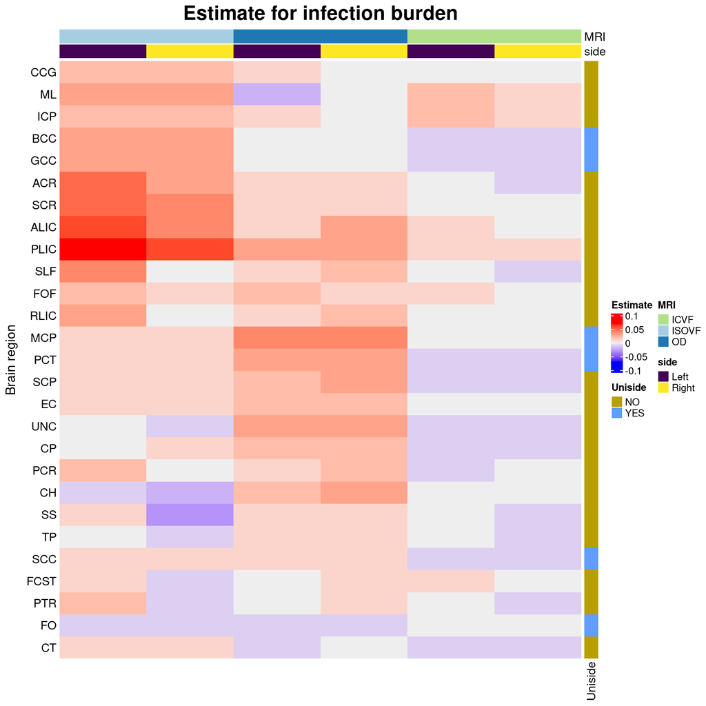

```r
mat <-
  d_dedup |>
  make_matrix(matrix_col = contains("estimate"), rowname_col = region)


# o1 = seriate(dist(mat), method = "OLO")
# o1 = seriate(dist(mat), method = "MDS")
o1 = seriate(dist(mat), method = "MDS_angle")


# d_dedup |>
#   make_matrix(matrix_col = contains("estimate"), rowname_col = region) %>%
mat |>
  Heatmap(
   name = "Estimate",
   show_row_names = TRUE,
   cluster_columns = FALSE,
   cluster_rows = FALSE,
   row_order = get_order(o1),

   # Title
   row_title = "Brain region",
   row_title_side = "left",
   column_title = "Estimate for infection burden",
   column_title_gp = gpar(fontsize = 20, fontface = "bold"),

   # Names
   row_names_side = "left",
   # column_names_rot = 60,
   # column_names_centered = TRUE,
   show_column_names = FALSE,

   # Annotation
   right_annotation = row_ha,
   top_annotation = column_ha
  )
```